# Replication of “On the Precipice of a ‘Majority-Minority’ America: Perceived Status Threat From the Racial Demographic Shift Affects White Americans’ Political Ideology” by Craig & Richeson (2014, Psychological Science)

Stacia King (staciak@stanford.edu)

December 13, 2021

## Introduction

Craig & Richeson, 2014, used an online experiment to unpack the link between racial demographic shifts and the endorsement of conservatism in white Americans. The study found white Americans leaned more conservative, and supported conservative policies more, after being primed with racial demographic shifts in favor of current minority groups. In this project I will look to see if results reveal a main effect of experimental condition (levels of group status threat) on overall policy attitudes, as was demonstrated in Study 3a.

### Links

Project repository (on Github): [craig2014](https://github.com/psych251/craig2014.git)

Original paper (as hosted in your repo): [view pdf](https://github.com/psych251/craig2014/blob/1af6af3af7d70e11185a62bc317543f77e10cde1/original_paper.pdf)

Open Practice: [original stimuli](https://osf.io/dzv6r/osffiles/PS14_Craig_Richeson_manipulations.pdf/)

Survey Link: [here](https://stanforduniversity.qualtrics.com/jfe/form/SV_bdaehc8gdxxRGJ0)

## Methods

### Power Analysis

An a priori power analysis was conducted using G*Power3 (Faul, Erdfelder, Lang, & Buchner, 2007) the original effect size (ηp^2 = .06), and an alpha of .05. To achieve 80%, 90%, and 95% power, total samples of 155, 202, and 246 participants, respectively, were required.

### Planned Sample

Financial resources limit the study to attempt an 80% replication. Resources may prevent this goal from being met. The sample will be limited to white American citizens who were born in the United States. I’ll be excluding mixed-raced white people, people who do not pass the article comprehension check, and people who report having read the stimuli before.

### Materials

“Participants first read an alleged press release”

### Procedure

“Participants read about the projected U.S. racial shift or a national shift in geographic mobility. They then completed measures assessing the potential mediators and reported their support for several policies.”

Some potential mediator items included in the original study were excluded in this replication. Namely, system threat and system justification.

### Analysis Plan

**Baseline Ideology Measure**

“This baseline ideology measure included two items; participants indicated the degree to which they endorsed ‘aspects of conservative political ideology’ and ‘aspects of liberal political ideology’ (1 = strongly disagree, 7 = strongly agree). Because these items were highly correlated…, we reverse-scored the liberalism item and averaged scores for the two items to create an index of relative preference for conservative (vs. liberal) ideology.”

**General Analysis & Covariates**

“… reported analyses for Studies 3a and 3b are ANCOVAs with experimental condition as the independent variable and demographic characteristics and baseline political ideology as covariates.”

The specified demographic characteristics are used as covariates are participants’ gender, age, education level, in addition to baseline political ideology.

**Exclusion Criteria**

“…participants who answered one of the article-comprehension items incorrectly (i.e., who incorrectly identified Whites as the group with the fastest increase) and… responded incorrectly to an attention-check item were excluded from analyses.”

**Conservative-policy Endorsement Score**

The response scales for policy-support items ranged from 1, *strongly opposed*, to 7, *strongly in favor*. The response scales for policy-change items ranged from 1, *increased a lot*, to 5, *decreased a lot*. …responses were standardized and averaged to create composites. For Study 3a, we computed [an index] of overall conservative-policy endorsement…"

**Clarify key analysis of interest here**

Study 3A results revealed a main effect of experimental condition on overall policy attitudes, F(2, 161) = 4.92, p = .008, ηp2 = .06.

I will use ANCOVAs with experimental condition as the independent variable, and demographic characteristics (gender, age, education level) and baseline political ideology as covariates.

### Differences from Original Study

**In Study Design:**

This study will reflect modern, socially acceptable and inclusive, identity categories. This study will also shorter, excluding many of the related, but non-main-focus items and measures. More specifically, the original study included questions and topics that this study will not, but that might have intensified the priming effect (i.e. sexual orientation, an item on racial identity, and on American culture change).

**In Data:**

This study collects gender information and not sex information because 1) it is socially appropriate and inclusive and 2) as it is a social psychological experiment, and gender as a social category, it seems more appropriately correlated then sex. So the demographics of the sample in this replication attempt will likely be different considering there are more identity options. Additionally, the original study looked at sex, and was heavily skewed male, and didn’t comprise of a representative proportion of white American females.

**In the World:**

The social climate has varied drastically in numerous waves and directions since the original study was conducted in 2012. Including, a global pandemic that has altered life as we know it in known and unknown ways. Socially, identities and norms have even changed around race & gender. This study will reflect modern norms, whereas these norms may not have been as prevalent or known at the time of the original experiment. The reality of shifting racial demographics is almost certainly more widely known now, than it was a decade ago, so the racial threat manipulation’s ability to induce group status threat may differ. According to publishing authors, this study has been replicated numerous times and may be well known in the online data collection communities. U.S. citizens, also are not living with a sitting Black president, as was the case when the original study took place, so this may change overall salience of group status threat.

## Results

### Data preparation

Data preparation following the analysis plan.

```r
###Data Preparation

####Load Relevant Libraries and Functions

library(tidyverse)
library(qualtRics)
library(car) #to check Homogeneity of Variances & run ANCOVA model
library(multcomp) #to see if/how groups are different from each other
library(lsr) #For calculating partial eta squared

#### Authenticate API

#qualtrics_api_credentials(api_key = "*Removed because MYOB*", base_url = "stanforduniversity.ca1.qualtrics.com", install = T)

#### Import data

qualtricsData <- fetch_survey(surveyID = "SV_bdaehc8gdxxRGJ0", force_request = T, label = FALSE, convert = FALSE, start_date = "2021-12-01" )
## Save Data to computer
write_csv(qualtricsData, "./newData/qualtricsData.csv")

#### Data exclusion / filtering - aka keep if true
filteredData = qualtricsData %>%
  filter(
    Consent == "1",     # Accept
    Race1_3 == "1",     # Marked White
    Citizen == "1",     # US Citizen
    primeRepeat != "1", # Hasn't read stimuli before
    groupGrowth == "4" || is.na(groupGrowth),     #All following are attention checks
    whitePopChange != "1" || whitePopChange != "2" || is.na(whitePopChange),
    !(Condition == "Status Threat" & groupPower == "1"),
    !(Condition == "Assuaged Threat" & groupPower == "2"),
    !(Condition == "Control" & groupMove == "1"),
    areaGrowth == "2" || is.na(areaGrowth)
    )

#### Prepare data for analysis - create columns etc.
cleanedData = filteredData %>%
  dplyr::select(c(ProlificID, ConservativeIdeo:GenPartyAffiliation_4_TEXT, statusThreatPercept:GenPolSpectrum, Age:Education, Condition, Gender1))

# Create Baseline Ideology
cleanedData = cleanedData %>%
  mutate(BaselineIdeo = (ConservativeIdeo + LiberalIdeo)/2)

# Create Composite Politics Score
cleanedData = cleanedData %>%
  mutate(
  standardImmCiti = (ImmigrantCitizenship-mean(ImmigrantCitizenship))/sd(ImmigrantCitizenship),
  standardImmNum = (ImmigrationNumber-mean(ImmigrationNumber))/sd(ImmigrationNumber),
  standardMilitary = (MilitaryFund -mean(MilitaryFund))/sd(MilitaryFund),
  standardAffAct = (AffirmativeAction - mean(AffirmativeAction))/sd(AffirmativeAction),
  standardHealth = (Healthcare - mean(Healthcare))/sd(Healthcare),
  standardEngLang = (EnglishNationalLang - mean(EnglishNationalLang))/sd(EnglishNationalLang),
  standardMarriage = (MarriageRights - mean(MarriageRights))/sd(MarriageRights),
  standardPrisons = (Prisons - mean(Prisons))/sd(Prisons)
  )

# Create Composite Conservative Ideology Score
cleanedData = cleanedData %>%
   mutate(conservativeScore = (standardImmCiti + standardImmNum + standardMilitary + standardAffAct +standardHealth +standardEngLang + standardMarriage + standardPrisons))
```

### Confirmatory analysis

The analyses as specified in the analysis plan.

```r
### Run Descriptives
## Summary
cleanedData %>%
  dplyr::select(Condition, Age, Gender1, BaselineIdeo, Education, conservativeScore) %>%
  summary()
```

```
##   Condition              Age           Gender1       BaselineIdeo
##  Length:114         Min.   :18.00   Min.   :1.000   Min.   :1.000
##  Class :character   1st Qu.:26.00   1st Qu.:1.000   1st Qu.:1.500
##  Mode  :character   Median :30.00   Median :2.000   Median :2.500
##                     Mean   :33.73   Mean   :1.544   Mean   :2.939
##                     3rd Qu.:41.00   3rd Qu.:2.000   3rd Qu.:4.000
##                     Max.   :71.00   Max.   :3.000   Max.   :7.000
##    Education     conservativeScore
##  Min.   :1.000   Min.   :-6.5962
##  1st Qu.:3.000   1st Qu.:-3.1193
##  Median :5.000   Median :-0.5452
##  Mean   :4.439   Mean   : 0.0000
##  3rd Qu.:5.000   3rd Qu.: 2.3630
##  Max.   :8.000   Max.   :10.0361
```

```r
## Mean & SD
cleanedData %>%
  group_by(Condition) %>%
  summarise(meanCScore = mean(conservativeScore), sdCScore = sd(conservativeScore))
```

```
## # A tibble: 3 x 3
##   Condition       meanCScore sdCScore
##   <chr>                <dbl>    <dbl>
## 1 Assuaged Threat     -0.721     3.82
## 2 Control              0.221     4.79
## 3 Status Threat        0.271     3.51
```

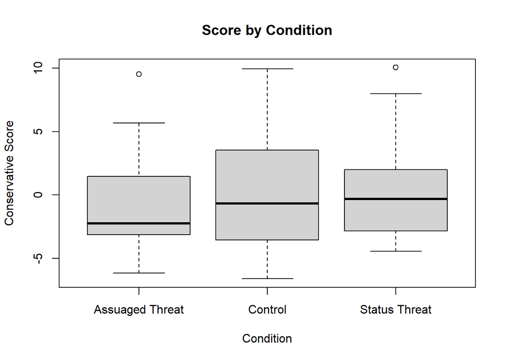

```r
## Visualize Data
boxplot(conservativeScore ~ Condition, data = cleanedData, main = "Score by Condition", xlab = "Condition", ylab = "Conservative Score")
```

```r
## Check Assumptions

"1. The covariate(s) and the treatment are independent"
```

```
## [1] "1. The covariate(s) and the treatment are independent"
```

```r
## AKA models are significantly different

ageModel <- aov(Age ~ Condition, data = cleanedData)
summary(ageModel)
```

```
##              Df Sum Sq Mean Sq F value Pr(>F)
## Condition     2     40   20.23   0.151   0.86
## Residuals   111  14854  133.82
```

```r
genderModel <- aov(Gender1 ~ Condition, data = cleanedData)
summary(genderModel)
```

```
##              Df Sum Sq Mean Sq F value Pr(>F)
## Condition     2   0.72  0.3598   1.265  0.286
## Residuals   111  31.56  0.2843
```

```r
baseIdeoModel <- aov(BaselineIdeo ~ Condition, data = cleanedData)
summary(baseIdeoModel)
```

```
##              Df Sum Sq Mean Sq F value Pr(>F)
## Condition     2   1.45   0.724   0.257  0.774
## Residuals   111 313.12   2.821
```

```r
educationModel <- aov(Education ~ Condition, data = cleanedData)
summary(educationModel)
```

```
##              Df Sum Sq Mean Sq F value Pr(>F)
## Condition     2   1.11  0.5542   0.278  0.758
## Residuals   111 220.96  1.9906
```

```r
"2. Verify the variances among the groups are not equal"
```

```
## [1] "2. Verify the variances among the groups are not equal"
```

```r
leveneTest(conservativeScore ~ Condition, data = cleanedData)
```

```
## Levene's Test for Homogeneity of Variance (center = median)
##        Df F value  Pr(>F)
## group   2  2.5212 0.08496 .
##       111
## ---
## Signif. codes:  0 '***' 0.001 '**' 0.01 '*' 0.05 '.' 0.1 ' ' 1
```

```r
## Run ANCOVA Analysis

ancovaModel <- aov(conservativeScore ~ Condition + Age + BaselineIdeo + Gender1  + Education, data = cleanedData)
Anova(ancovaModel, type="III")
```

```
## Anova Table (Type III tests)
##
## Response: conservativeScore
##               Sum Sq  Df  F value    Pr(>F)
## (Intercept)    75.53   1  13.4690 0.0003801 ***
## Condition       4.83   2   0.4305 0.6512996
## Age             7.18   1   1.2805 0.2603316
## BaselineIdeo 1157.66   1 206.4413 < 2.2e-16 ***
## Gender1         0.40   1   0.0706 0.7909692
## Education      21.66   1   3.8624 0.0519717 .
## Residuals     600.02 107
## ---
## Signif. codes:  0 '***' 0.001 '**' 0.01 '*' 0.05 '.' 0.1 ' ' 1
```

```r
#Calculate partial eta squared
etaSquared(ancovaModel)
```

```
##                    eta.sq  eta.sq.part
## Condition    0.0025564712 0.0079826517
## Age          0.0038020389 0.0118259760
## BaselineIdeo 0.6129509637 0.6586282269
## Gender1      0.0002096355 0.0006594248
## Education    0.0114679445 0.0348395160
```

There is no original graph.

### Exploratory analyses

```r
## Run ANCOVA Analysis no Covariates

ancovaModel <- aov(conservativeScore ~ Condition, data = cleanedData)
Anova(ancovaModel, type="III")
```

```
## Anova Table (Type III tests)
##
## Response: conservativeScore
##              Sum Sq  Df F value Pr(>F)
## (Intercept)   15.09   1  0.8965 0.3458
## Condition     20.29   2  0.6027 0.5491
## Residuals   1868.37 111
```

```r
#Calculate partial eta squared
etaSquared(ancovaModel)
```

```
##               eta.sq eta.sq.part
## Condition 0.01074317  0.01074317
```

[output not shown]

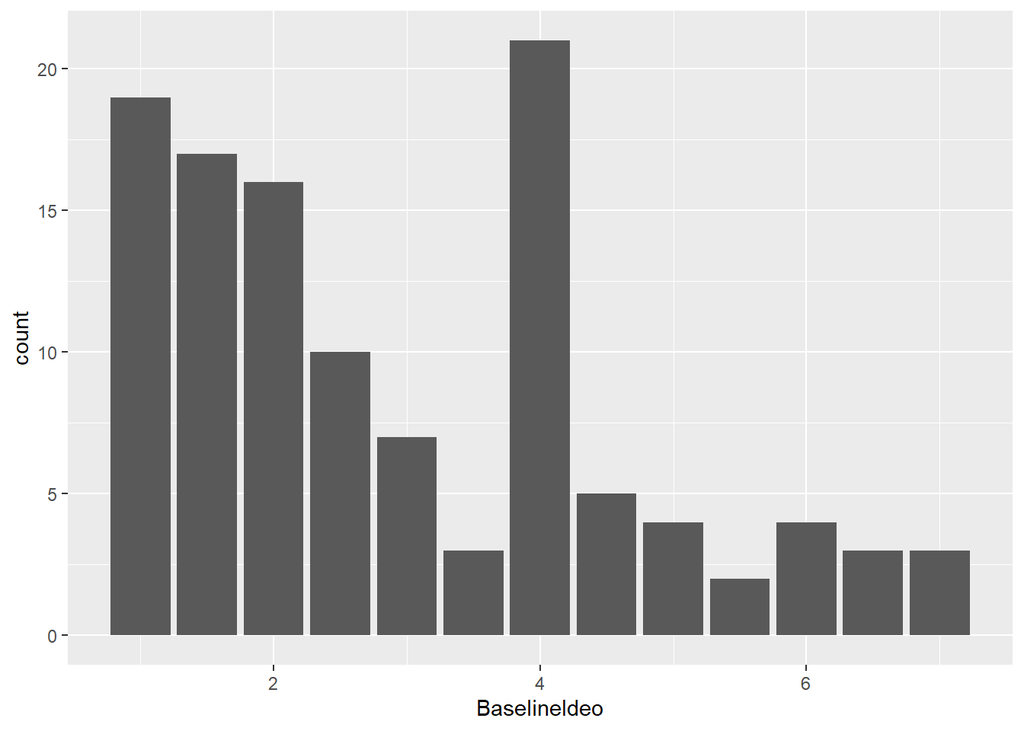

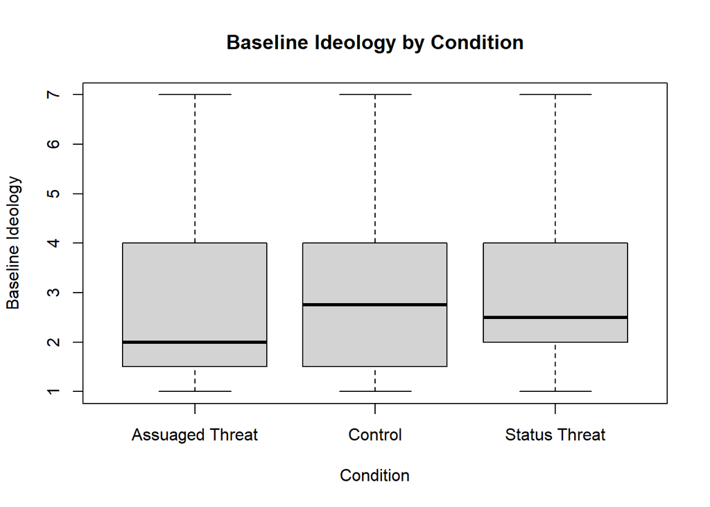

## Discussion

### Summary of Replication Attempt

I believe the primary results show there is not a detectable difference in conservative score based on condition. I think the ANOVA table shows that the difference in the the conservative score is a function of the baseline ideology. However, this F score is very high, F = 206.44***. With n below what was necessary to have 80% percent in order to see an effect size, this study failed to replicate the original result.